# LASSO Predictive Models for IgA Immune Cell Frequencies

IgA Experiment

Walter Moises Avila

First made: April 4th, 2023. Last updated May 25th, 2023

# R Markdown (RMD)

This is an R Markdown file. It is a document that combines text, code, and results into a single file, allowing researchers to seamlessly blend narrative explanations with executable code in the R programming language.

# Introduction

**Key terms:** dietary fiber, microbiota, bacterial diversity, 16s reads, IgA, IgA plasma cells, IgA B cells, LASSO regression, overfitting, multicollinearity, cross-validation, training set, test set, prediction error

Motivated by our previous experiments investigating the effects of dietary fiber on intestinal Th17 and intraepithelial T cell development, we have observed that a decreased intake of dietary fiber alters the composition of the small intestinal microbiota and negatively impacts T cell development in this region (**Figure 1**).

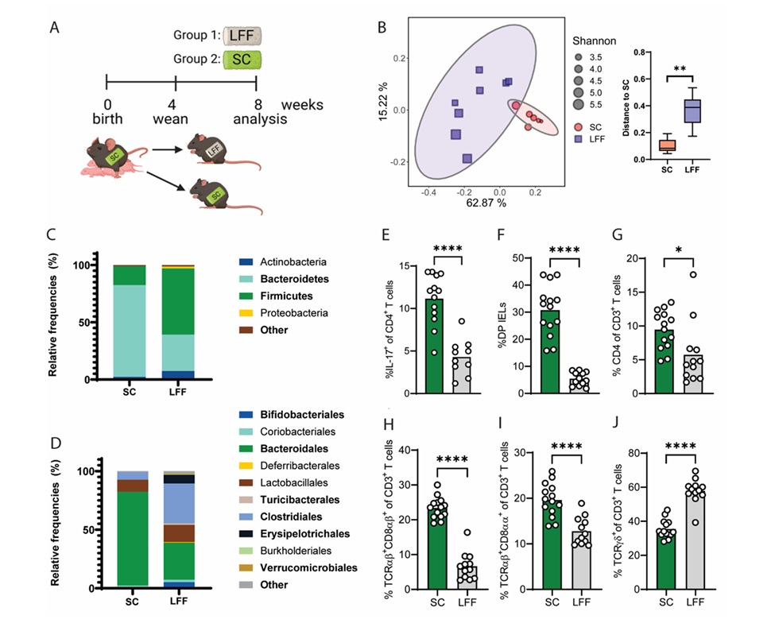

These findings provide additional evidence supporting the connection between immune function and bacterial diversity, influenced by changes in dietary fiber. Moreover, these results suggest the possibility of a similar relationship between bacterial diversity and the abundance of plasma and B cells responsible for IgA production.

Therefore, for the quantitative portion of my research, I explore the relationship between bacterial diversity and the abundance of plasma and B cells that produce IgA in mice. To achieve this, I developed Least Absolute Shrinkage and Selection Operator (LASSO) regression models that predict IgA plasma and B cell frequencies in each mouse’s profile from Jarreth’s IgA immune cell data using the relative bacterial order read proportions from Charlotte’s and Naomi’s G1 Level Four data as the explanatory variables.

LASSO regression is a regularization method. Regularization is the process of shrinking (“regularizing”) the linear regression coefficient estimates towards zero, resulting in a less complex and more generalizable model with smaller and/or fewer coefficients to reduce model over fitting. Moreover, compared to other regression techniques, the LASSO approach is particularly effective for models with multiple variables showing high multicollinearity.

Multicollinearity refers to when two or more independent variables in a statistical model highly correlate with each other. This can pose challenges because it becomes difficult to determine the individual effects of each variable on the dependent variable. Furthermore, the presence of high correlation between variables can lead to unstable and unreliable coefficient estimates. It may also make it difficult to identify which specific variables truly explain the dependent variable. In the context of this IgA experiment, multicollinearity could arise if certain bacterial orders in the microbiota composition are strongly correlated with each other. This can affect the accuracy and interpretability of our results.

LASSO works by applying a penalty term to shrink the size of coefficients to zero in the model. By optimizing this penalty term through cross-fold validation, we can determine the most important bacterial orders that explain immune cell frequencies.

By developing this model, we hope to identify the bacterial orders that best predict immune cell frequencies in mice fed different diets. This knowledge willguide us in further investigating these specific bacteria in the IgA experiment and its 16s results.

Through this analysis, we aim to deepen our understanding of the intricate relationship between dietary fiber, microbiota composition, and immune cell development in the small intestine.

Throughout this document, I provide step-by-step explanations, code snippets, and visualizations to facilitate comprehension and replication of our analysis.

# Importing Required Packages

To support our analysis, we must import several packages in our code. These packages are collections of pre-written code and functions that provide additional functionality to the default R programming language. Here’s a brief explanation of the packages we used:

1. `readxl`: Allows us to read Excel files containing data.
2. `tidyverse`: Provides tools for data manipulation and organization.
3. `glmnet`: Enables fitting a LASSO regression model.
4. `knitr`: Facilitates creating dynamic and reproducible reports.

These packages were utilized to read and manipulate data, fit the LASSO regression model, and generate this comprehensive report with code, explanations, and results.

# Importing and Normalizing Data

Here, using the `read_excel` function, I import the excel file containing the group 1 level 4 (order) bacteria taxonomic data from CR and NR’s experiments. Additionally, I import another excel file containing the IgA plasma and B cell frequencies from Jarreth’s B-cell panel experiments. Any “NAs” in the order data were replaced with $0.$

```r
# Taxonomic data from CR and NR's experiments
G1_level_4 <- read_excel("G1_level-4.xlsx")

# IgA Plasma and B Cell Frequencies from Jarreth's B-cell panel experiments
IgA_Plasma_B_Cell_Data <- read_excel("IgA Plasma and B Cell Data from Jarreth's 2023.01_B-cell-panel.xlsx")
```

**NOTE:** The label “RNN” denotes the CON/LFF diet while “CR_RRR” denotes the CON/CON diet. Recall that CON can be also be labeled as “SCD” or “SC.”

```r
G1_level_4 <- G1_level_4 %>%
   mutate(newSum = select_if(., is.numeric) %>%
                       reduce(`+`)) %>%
   mutate_if(is.numeric, list(~ ./newSum)) %>%
   select(-newSum)

# Viewing all mice and only 5 bacteria orders
knitr::kable(G1_level_4[,1:5])
```

| index | k__Bacteria;p__Bacteroidetes;c__Bacteroidia;o__Bacteroidales | k__Bacteria;p__Firmicutes;c__Bacilli;o__Lactobacillales | k__Bacteria;p__Firmicutes;c__Clostridia;o__Clostridiales | k__Bacteria;p__Firmicutes;c__Erysipelotrichi;o__Erysipelotrichales |
| --- | --- | --- | --- | --- |
| CR_RNN1 | 0.2235541 | 0.0116294 | 0.6795864 | 0.0004509 |
| CR_RNN2 | 0.3617836 | 0.0928774 | 0.2371216 | 0.0036004 |
| CR_RNN3 | 0.1755415 | 0.1594983 | 0.4582950 | 0.0008022 |
| CR_RNN4 | 0.1369425 | 0.0654330 | 0.6115958 | 0.0049132 |
| CR_RNN5 | 0.5757627 | 0.0515146 | 0.1824617 | 0.1354366 |
| CR_RNN6 | 0.5891596 | 0.0101000 | 0.1774158 | 0.1459015 |
| CR_RNN7 | 0.3365749 | 0.0798193 | 0.2471622 | 0.2914825 |
| CR_RNN8 | 0.1403210 | 0.6669579 | 0.1243152 | 0.0283692 |
| CR_RRR3 | 0.7765834 | 0.0649104 | 0.1277887 | 0.0000000 |
| CR_RRR4 | 0.9165437 | 0.0325430 | 0.0125933 | 0.0000416 |
| CR_RRR5 | 0.8716779 | 0.0679851 | 0.0231258 | 0.0001413 |
| CR_RRR6 | 0.8320223 | 0.1114482 | 0.0251266 | 0.0000628 |
| CR_RRR7 | 0.6232366 | 0.2120737 | 0.1185342 | 0.0001483 |
| CR_RRR8 | 0.7838708 | 0.1547066 | 0.0426109 | 0.0000000 |

Now, let’s view Jarreth’s B-cell panel data. It contains data from n = 5 RNN and n = 5 CR_RRR mice. The two variables of interest are Lamina Propria (LP) IgA Plasma Cells and LP IgA B Cells.

```r
knitr::kable(IgA_Plasma_B_Cell_Data)
```

| group | diet born | weaned to | swap | LP IgA Plasma Cells | LP IgA B Cells |
| --- | --- | --- | --- | --- | --- |
| RNN | CON | NFF | CON-NFF | 0.0420 | 0.0400 |
| RNN | CON | NFF | CON-NFF | 0.0615 | 0.4475 |
| RNN | CON | NFF | CON-NFF | 0.0640 | 0.6300 |
| RNN | CON | NFF | CON-NFF | 0.0690 | 0.7300 |
| RNN | CON | NFF | CON-NFF | 0.0710 | 0.3900 |
| CR_RRR | CON | CON | none CON | 0.2500 | 3.4300 |
| CR_RRR | CON | CON | none CON | 0.0780 | 1.4700 |
| CR_RRR | CON | CON | none CON | 0.1200 | 1.0400 |
| CR_RRR | CON | CON | none CON | 0.1900 | 0.5000 |
| CR_RRR | CON | CON | none CON | 0.2600 | 0.5900 |

With both datasets prepared, the next step is to merge the order variables from the G1 dataset with the immune cell frequencies obtained from Jarreth’s data. To begin this process, I split Charlotte’s G1 order data frame into two separate datasets, each corresponding to the RNN or CR_RRR group.

```r
RNN_G1_level_4 <- G1_level_4 %>%
  filter(group == "RNN")

CR_RRR_G1_level_4 <- G1_level_4 %>%
  filter(group == "CR_RRR")
```

Subsequently, I proceed to randomly select $5$ mice from the RNN group and $5$ mice from the CR_RRR group, along with their respective taxonomic data observations, from the prepared dataframes. By using `set.seed(10)`, the selection of these $10$ mice and their taxonomic data will remain consistent across multiple runs of the code chunk. This ensures reproducibility and allows us to work with the same set of randomly selected mice for subsequent analyses.

```r
set.seed(10)

Five_Random_RNN_Mice <- RNN_G1_level_4[sample(1:nrow(RNN_G1_level_4), 5),]

Five_Random_RNN_Mice <- Five_Random_RNN_Mice[,2:70]

Five_Random_CR_RRR_Mice <- CR_RRR_G1_level_4[sample(1:nrow(CR_RRR_G1_level_4), 5),]

Five_Random_CR_RRR_Mice <- Five_Random_CR_RRR_Mice[,2:70]
```

Having obtained the taxonomic data for $5$ randomly selected CR_RRR mice and $5$ randomly selected RNN mice, I proceed to integrate this information into the dataframe that already contains the IgA immune cell frequencies for an equivalent number of CR_RRR and RNN mice.

This results in a final dataframe, called `IgA_Plasma_B_Cell_and_G1_Taxonomic_Data` that contains the immune cell frequencies and bacteria order proportions for $5$ CR_RRR and $5$ RNN mice.

```r
Random_RRN_CR_RRR_Order_Data <- rbind(Five_Random_RNN_Mice,Five_Random_CR_RRR_Mice)

IgA_Plasma_B_Cell_and_G1_Taxonomic_Data <- cbind(IgA_Plasma_B_Cell_Data,Random_RRN_CR_RRR_Order_Data)

knitr::kable(head(IgA_Plasma_B_Cell_and_G1_Taxonomic_Data)[,1:8])
```

| group | diet born | weaned to | swap | LP IgA Plasma Cells | LP IgA B Cells | k__Bacteria;p__Bacteroidetes;c__Bacteroidia;o__Bacteroidales | k__Bacteria;p__Firmicutes;c__Bacilli;o__Lactobacillales |
| --- | --- | --- | --- | --- | --- | --- | --- |
| RNN | CON | NFF | CON-NFF | 0.0420 | 0.0400 | 0.1755415 | 0.1594983 |
| RNN | CON | NFF | CON-NFF | 0.0615 | 0.4475 | 0.2235541 | 0.0116294 |
| RNN | CON | NFF | CON-NFF | 0.0640 | 0.6300 | 0.3617836 | 0.0928774 |
| RNN | CON | NFF | CON-NFF | 0.0690 | 0.7300 | 0.1369425 | 0.0654330 |
| RNN | CON | NFF | CON-NFF | 0.0710 | 0.3900 | 0.1403210 | 0.6669579 |
| CR_RRR | CON | CON | none CON | 0.2500 | 3.4300 | 0.7838708 | 0.1547066 |

# LASSO Model to Predict LP IgA Plasma Cells

## Separating Datasets

After merging the taxonomic data and IgA plasma and B cell data into a single dataframe, we proceed to divide this dataframe into two separate ones based on mouse identity. Subsequently, we calculate summary statistics to gain insights into the IgA plasma and B cell frequencies within each of the resulting dataframes. This analysis provides a overview of the distribution and characteristics of IgA immune cell populations in relation to the dietary regime of the mice.

```r
RNN_IgA_Taxonomic_Data <- IgA_Plasma_B_Cell_and_G1_Taxonomic_Data %>%
  filter(group == "RNN")

CR_RRR_IgA_Taxonomic_Data <- IgA_Plasma_B_Cell_and_G1_Taxonomic_Data %>%
  filter(group == "CR_RRR")

summary(RNN_IgA_Taxonomic_Data[,1:6])
```

```
##     group            diet born          weaned to             swap
##  Length:5           Length:5           Length:5           Length:5
##  Class :character   Class :character   Class :character   Class :character
##  Mode  :character   Mode  :character   Mode  :character   Mode  :character
##
##
##
##  LP IgA Plasma Cells LP IgA B Cells
##  Min.   :0.0420      Min.   :0.0400
##  1st Qu.:0.0615      1st Qu.:0.3900
##  Median :0.0640      Median :0.4475
##  Mean   :0.0615      Mean   :0.4475
##  3rd Qu.:0.0690      3rd Qu.:0.6300
##  Max.   :0.0710      Max.   :0.7300
```

```r
summary(CR_RRR_IgA_Taxonomic_Data[,1:6])
```

```
##     group            diet born          weaned to             swap
##  Length:5           Length:5           Length:5           Length:5
##  Class :character   Class :character   Class :character   Class :character
##  Mode  :character   Mode  :character   Mode  :character   Mode  :character
##
##
##
##  LP IgA Plasma Cells LP IgA B Cells
##  Min.   :0.0780      Min.   :0.500
##  1st Qu.:0.1200      1st Qu.:0.590
##  Median :0.1900      Median :1.040
##  Mean   :0.1796      Mean   :1.406
##  3rd Qu.:0.2500      3rd Qu.:1.470
##  Max.   :0.2600      Max.   :3.430
```

## Creating Training and Test Datasets

To proceed, our next step involves creating training and test datasets using the two dataframes. This process entails training the LASSO model on a random subset of four CR_RRR and RNN mice, while evaluating its performance on a separate CR_RRR and RNN mouse from each dataset. By conducting this procedure, we can assess the model’s predictive capabilities on unseen mice and ascertain its effectiveness in predicting IgA immune cell frequencies specific to both CR_RRR and RNN groups.

In each code chunk below, I create a training and test dataset for the CR_RRR and RNN mice. Recall that each training set has four randomly selected mice and each test set has one mouse.

The names of the datasets are:

1. `train_RNN`
2. `test_RNN`
3. `train_CR_RRR`
4. `test_CR_RRR`

### RNN

```r
set.seed(100)

index_RNN = sample(1:nrow(RNN_IgA_Taxonomic_Data),0.8*nrow(RNN_IgA_Taxonomic_Data))

train_RNN = RNN_IgA_Taxonomic_Data[index_RNN,]

test_RNN_output <- RNN_IgA_Taxonomic_Data[-index_RNN,]$`LP IgA Plasma Cells`

test_RNN_output_Bcells <- RNN_IgA_Taxonomic_Data[-index_RNN,]$`LP IgA B Cells`

test_RNN = RNN_IgA_Taxonomic_Data[-index_RNN,]

test_RNN<- test_RNN[,7:75]
```

### CR_RRR

```r
set.seed(100)

index_CR_RRR = sample(1:nrow(CR_RRR_IgA_Taxonomic_Data),0.8*nrow(CR_RRR_IgA_Taxonomic_Data))

train_CR_RRR = CR_RRR_IgA_Taxonomic_Data[index_CR_RRR,]

test_CR_RRR_output <- CR_RRR_IgA_Taxonomic_Data[-index_CR_RRR,]$`LP IgA Plasma Cells`

test_CR_RRR = CR_RRR_IgA_Taxonomic_Data[-index_CR_RRR,]

test_CR_RRR <- test_CR_RRR[,7:75]
```

## Preparing Inputs for LASSO Model: Predicting LP IgA Plasma Cell Frequencies

Now, to fit the LASSO models using the `glmnet`package and function, we follow a specific procedure. First, for each training set, we extract the order relative read proportions data and the LP IgA Plasma cell frequency data.

We then convert these data into matrices, where the order relative read proportions data serve as the x-values and the LP IgA Plasma cell frequency data as the y-values. These matrices are used as inputs for the `glmnet` function to train and fit the LASSO model.

```r
cols <- colnames(train_CR_RRR[,7:75])

train_RNN_pred <- as.matrix(train_RNN[cols])
train_RNN_output <- as.matrix(train_RNN$`LP IgA Plasma Cells`)

train_CR_RRR_pred <- as.matrix(train_CR_RRR[cols])
train_CR_RRR_output <- as.matrix(train_CR_RRR$`LP IgA Plasma Cells`)
```

## Finding Optimal Lambdas ($\lambda$)

After preparing our inputs for the `glmnet` function, we must optimize the lambda parameter. $\lambda$ controls the amount of regularization applied, with higher lambda values leading to more coefficients being shrunk towards zero.

To find the “optimal” $\lambda$ value for the LASSO models predicting LP IgA Plasma Cell frequencies for the CR_RRR and RNN mice, we use a method known as cross-validation. This technique assesses the model’s performance on different subsets of the training data. In this case, we are using $20$-fold cross-validation (`nfolds` = $20$), which divides the training data into $20$ equal-sized subsets. The `glmnet::cv.glmnet()` function then fits multiple LASSO models on different combinations of the subsets and evaluates their performance.

The output of `cv.glmnet()` includes a range of $\lambda$ values and the corresponding mean squared error (MSE). This is shown below in the $\lambda$ vs MSE plots for each cross-validation process. Each plot shows two vertical dashed lines, corresponding to the $\lambda$ that gives the minimum MSE (referred to as `lambda.min`) and the $\lambda$ that gives the largest value of $\lambda$ within one standard error of the MSE (referred to as `lambda.1se`). Moreover, the numbers at the top of the plot show the number of predictors with non-zero coefficients at that particular $\lambda$ value.

We seek to extract the $\lambda$ value that minimizes the cross-validated error as the optimal $\lambda$ for each dataset.

### RNN

```r
RNN_optimal_lasso <- glmnet::cv.glmnet(x = train_RNN_pred, y = train_RNN_output, nfolds = 20, alpha = 1)
RNN_best_lambda <- RNN_optimal_lasso$lambda.min

print(RNN_best_lambda)
```

```
## [1] 0.0001931121
```

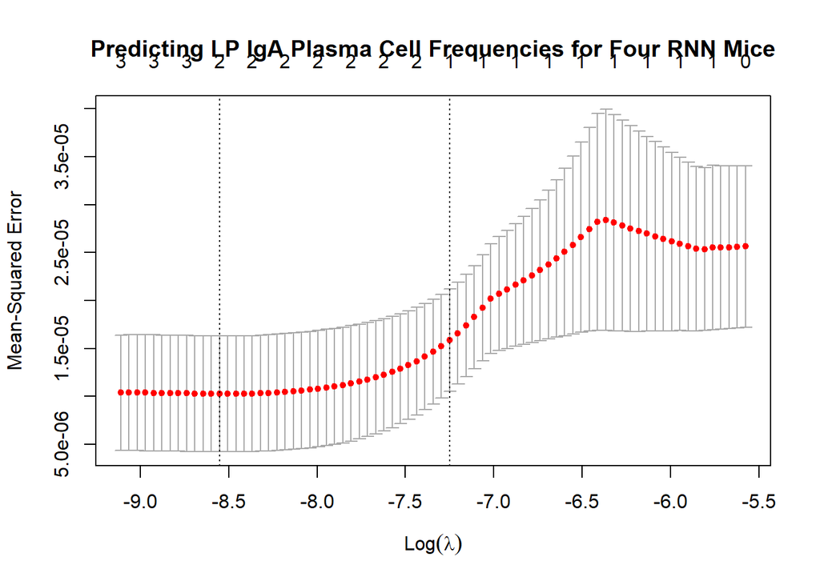

```r
plot(RNN_optimal_lasso, main = "Predicting LP IgA Plasma Cell Frequencies for Four RNN Mice")
```

### CR_RRR

```r
CR_RRR_optimal_lasso <- glmnet::cv.glmnet(x = train_CR_RRR_pred, y = train_CR_RRR_output, nfolds = 20, alpha = 1)
CR_RRR_best_lambda <- CR_RRR_optimal_lasso$lambda.min

print(CR_RRR_best_lambda)
```

```
## [1] 0.04671846
```

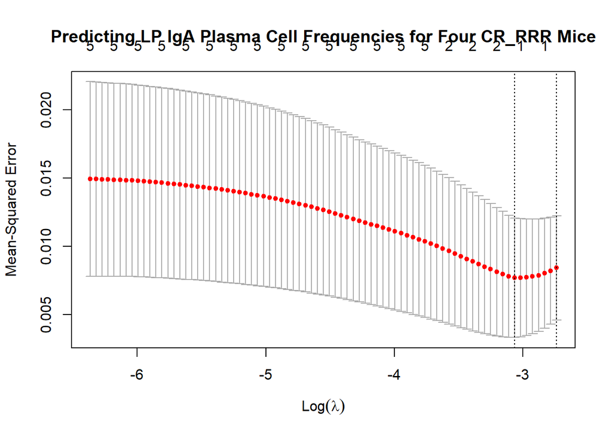

```r
plot(CR_RRR_optimal_lasso, main = "Predicting LP IgA Plasma Cell Frequencies for Four CR_RRR Mice")
```

## Running Lasso Regressions with Optimal $\lambda$ Values

Now that we have determined the optimal $\lambda$ values for predicting LP IgA Plasma Cell frequencies in CR_RRR and RNN mice, we proceed to build our final LASSO models using these $\lambda$ values. By fitting these models on the training data, we can identify the bacterial orders that have non-zero coefficients at the optimal $\lambda$. These non-zero coefficients indicate the bacterial orders that contribute significantly to the prediction of LP IgA Plasma Cell frequencies in CR_RRR and RNN mice.

### RNN

Here, we see which orders have non-zero coefficients at the optimal lambda as well as the $R^{2}$ value.

```r
lasso_model_RNN <- glmnet(train_RNN_pred, train_RNN_output, alpha = 1, lambda = RNN_best_lambda, standardize = TRUE)

list <- coef(lasso_model_RNN)[,1]

Plasma_Cells_RNN_NonZeroCoefs <- list[list!=0]

Plasma_Cells_RNN_NonZeroCoefs
```

```
##                                       (Intercept)
##                                        0.07092777
## k__Bacteria;p__Cyanobacteria;c__4C0d-2;o__MLE1-12
##                                       -1.26581185
##              k__Bacteria;p__TM7;c__TM7-3;o__EW055
##                                      -46.87416480
```

```r
lasso_model_RNN$dev.ratio
```

```
## [1] 0.9970603
```

For the RNN data, only two orders significantly explain LP IgA Plasma Cells at the optimal lambda. These are:

1. `k__Bacteria;p__Cyanobacteria;c__4C0d-2;o__MLE1-12`
2. `k__Bacteria;p__TM7;c__TM7-3;o__EW055`

The $R^{2}$ resulting from this fit is $R^{2} = 0.997.$

The LASSO regression model is therefore:

RNN LP IgA Plasma Cells = $0.0709 - 1.2658 \times \text{CyanobacteriaMLE1-12} - 46.87 \times \text{p__TM7;c__TM7-3;o__EW055}$

This model is interpreted as:

### CR_RRR

Now, we carry out the same process for the CR_RRR mice.

Here, we see which orders have non-zero coefficients at the optimal lambda as well as the $R^{2}$ value.

```r
lasso_model_CR_RRR <- glmnet(train_CR_RRR_pred, train_CR_RRR_output, alpha = 1, lambda = CR_RRR_best_lambda, standardize = TRUE)

list_2 <- coef(lasso_model_CR_RRR)[,1]

Plasma_Cells_CR_RRR_NonZeroCoefs <- list_2[list_2!=0]

Plasma_Cells_CR_RRR_NonZeroCoefs
```

```
##                                              (Intercept)
##                                                0.1353187
## k__Bacteria;p__Firmicutes;c__Clostridia;o__Clostridiales
##                                                0.3623024
```

```r
lasso_model_CR_RRR$dev.ratio
```

```
## [1] 0.4172103
```

For the CR_RRR data, only one order, Clostridiales, significantly explains LP IgA Plasma Cells at the optimal lambda.

$R^{2} = 0.417$

The LASSO regression model is therefore:

CR RRR LP IgA Plasma Cells = $0.135 + 0.362 \times \text{Clostridiales}$

This model is interpreted as:

## Testing PLasma Cell LASSO Models on Out-of-Sample Test Data

Recall that we had only one test observation of taxonomic data for one RNN mouse and only one test observation of taxonomic data for one CR_RRR mouse.

The difference in the actual and predicted LP IgA plasma cells is our estimate of out-of-sample performance for our two LASSO models that predict LP IgA Plasma Cells based off taxonomic information of the samples.

### RNN

```r
`MLE1-12` = test_RNN$`k__Bacteria;p__Cyanobacteria;c__4C0d-2;o__MLE1-12`

EW055 = test_RNN$`k__Bacteria;p__TM7;c__TM7-3;o__EW055`

test_RNN_pred = 0.07092777 - (1.26581185*`MLE1-12`) - (46.87416480*EW055)


print(test_RNN_pred - test_RNN_output)
```

```
## [1] 0.01917212
```

The prediction was off by $0.0191.$

### CR_RRR

```r
Clostridiales = test_CR_RRR$`k__Bacteria;p__Firmicutes;c__Clostridia;o__Clostridiales`


test_CR_RRR_pred = 0.1353187 + (0.3623024*Clostridiales)


print(test_CR_RRR_pred - test_CR_RRR_output)
```

```
## [1] -0.09924327
```

The prediction was off by $-0.09924.$

# LASSO Model to Predict LP IgA B Cells.

We repeat the same process but to predict LP IgA B cells this time.

## Preparing Inputs for LASSO Model

The x-value input is the same. We only need to change our output data to “LP IgA B Cells.” Therefore, we make new output variables to insert into our LASSO models: `train_RNN_output_Bcells` and `train_CR_RRR_output_Bcells` variables.

```r
train_RNN_output_Bcells <- as.matrix(train_RNN$`LP IgA B Cells`)


train_CR_RRR_output_Bcells <- as.matrix(train_CR_RRR$`LP IgA B Cells`)
```

## Finding Optimal $\lambda$ Values

### RNN

```r
RNN_optimal_lasso_Bcells <- glmnet::cv.glmnet(x = train_RNN_pred, y = train_RNN_output_Bcells, nfolds = 20, alpha = 1)
RNN_best_lambda_Bcells <- RNN_optimal_lasso_Bcells$lambda.min

print(RNN_best_lambda_Bcells)
```

```
## [1] 0.1354005
```

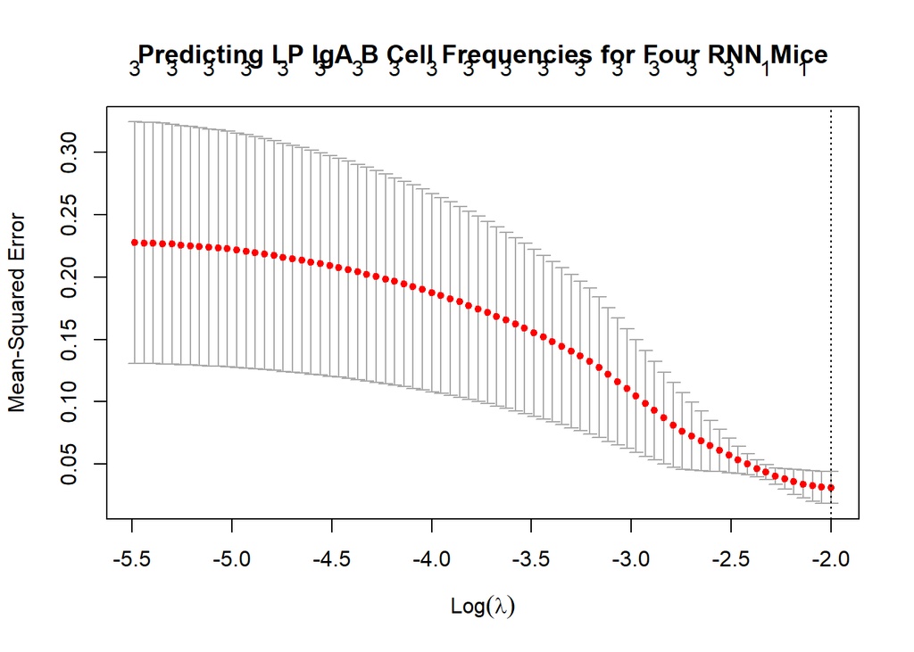

```r
plot(RNN_optimal_lasso_Bcells, main = "Predicting LP IgA B Cell Frequencies for Four RNN Mice")
```

### CR_RRR

```r
CR_RRR_optimal_lasso_Bcells <- glmnet::cv.glmnet(x = train_CR_RRR_pred, y = train_CR_RRR_output_Bcells, nfolds = 20, alpha = 1)
CR_RRR_best_lambda_Bcells <- CR_RRR_optimal_lasso_Bcells$lambda.min

print(CR_RRR_best_lambda_Bcells)
```

```
## [1] 0.1876844
```

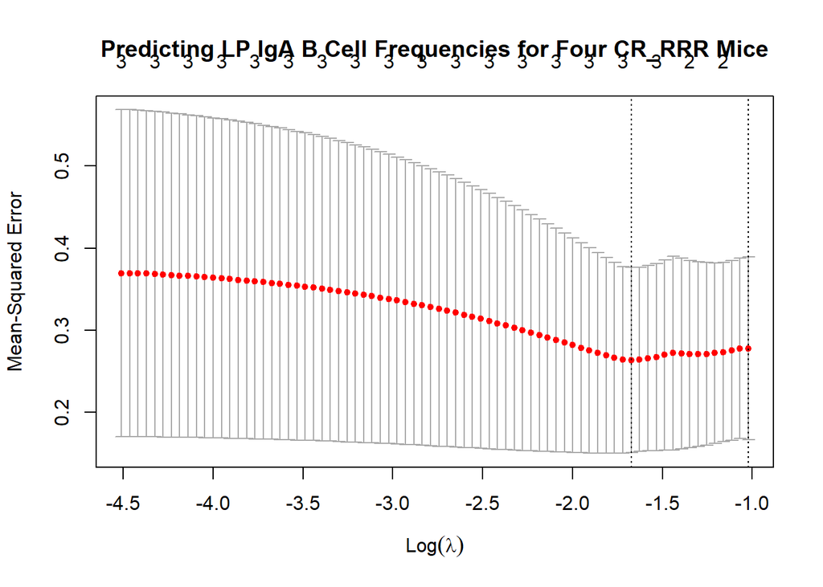

```r
plot(CR_RRR_optimal_lasso_Bcells,main = "Predicting LP IgA B Cell Frequencies for Four CR_RRR Mice")
```

## Running LASSO Regressions with Optimal $\lambda$ Values

### RNN

Here, we see which orders have non-zero coefficients at the optimal lambda as well as the $R^{2}$ value.

```r
lasso_model_RNNBCells <- glmnet(train_RNN_pred, train_RNN_output_Bcells, alpha = 1, lambda = RNN_best_lambda_Bcells, standardize = TRUE)

list <- coef(lasso_model_RNNBCells)[,1]

B_Cells_RNN_NonZeroCoefs <- list[list!=0]

B_Cells_RNN_NonZeroCoefs
```

```
## (Intercept)
##    0.549375
```

```r
lasso_model_RNNBCells$dev.ratio
```

```
## [1] 0
```

For the RNN data, no order significantly explains LP IgA B Cells at the optimal lambda.

Therefore, $R^{2} = 0$

### CR_RRR

```r
lasso_model_CR_RRRBCells <- glmnet(train_CR_RRR_pred, train_CR_RRR_output_Bcells, alpha = 1, lambda = CR_RRR_best_lambda_Bcells, standardize = TRUE)

list_2 <- coef(lasso_model_CR_RRRBCells)[,1]

B_Cells_CR_RRR_NonZeroCoefs <- list_2[list_2!=0]

B_Cells_CR_RRR_NonZeroCoefs
```

```
##                                                               (Intercept)
##                                                                 0.6043590
##                  k__Bacteria;p__Firmicutes;c__Clostridia;o__Clostridiales
##                                                                -0.4357604
## k__Bacteria;p__Proteobacteria;c__Gammaproteobacteria;o__Enterobacteriales
##                                                               223.8784213
##   k__Bacteria;p__Proteobacteria;c__Gammaproteobacteria;o__Xanthomonadales
##                                                               892.8010416
```

```r
lasso_model_CR_RRRBCells$dev.ratio
```

```
## [1] 0.7184672
```

For the CR_RRR data, only three orders, `Clostridiales`,`Enterobacteriales`,and `Xanthomonadales`, significantly explain LP IgA B Cells at the optimal lambda.

$R^{2} = 0.718.$

The LASSO regression model is therefore:

CR RRR LP IgA B Cells = $0.604 - 0.4357604 \times \text{Clostridiales} + 223.878 \times \text{Enterobacteriales} + 892.801 \times \text{Xanthomonadales}$

This model is interpreted as:

## Testing LASSO Model on Out-of-Sample Test Data

```r
Clostridiales_All_BCells = test_CR_RRR$`k__Bacteria;p__Firmicutes;c__Clostridia;o__Clostridiales`

Enterobacteriales_All = test_CR_RRR$`k__Bacteria;p__Proteobacteria;c__Gammaproteobacteria;o__Enterobacteriales`

Xanthomonadales_All = test_CR_RRR$`k__Bacteria;p__Proteobacteria;c__Gammaproteobacteria;o__Xanthomonadales`

test_CR_RRR_pred_BCells = 0.6043590 + ( -0.4357604*Clostridiales_All_BCells) + (223.8784213*Enterobacteriales_All) + (892.8010416*Xanthomonadales_All)


print(test_CR_RRR_pred_BCells - test_RNN_output_Bcells)
```

```
## [1] 0.8439052
```

# Summary

**LASSO Model Predicting LP IgA Plasma Cells for RNN Mice**

RNN LP IgA Plasma Cells = $0.0709 - 1.2658 \times \text{CyanobacteriaMLE1-12} - 46.87 \times \text{p__TM7;c__TM7-3;o__EW055}$

Optimal Lambda that Minimizes MSE: $λ=0.0001931121$

Out of Sample Error for One Test Point: $0.01917212$

Goodness-of-Fit: $R^{2} = 0.997.$

**LASSO Model Predicting LP IgA Plasma Cells for CR_RRR Mice**

CR RRR LP IgA Plasma Cells = $0.135 + 0.362 \times \text{Clostridiales}$

Optimal Lambda that Minimizes MSE: $λ=0.04671846$,

Out of Sample Error for One Test Point: $-0.09924327$

Goodness-of-Fit: $R^{2} = 0.417$

**LASSO Model Predicting LP IgA B Cells for RNN Mice**

Model Returned No Coefficients with size greater than 0

**LASSO Model Predicting LP IgA B Cells for CR_RRR Mice**

CR RRR LP IgA B Cells = $0.604 - 0.4357604 \times \text{Clostridiales} + 223.878 \times \text{Enterobacteriales} + 892.801 \times \text{Xanthomonadales}$

Optimal Lambda that Minimizes MSE: $λ=0.1876844$

Goodness-of-Fit: $R^{2} = 0.718.$

# Conclusions

Assuming that the relationships between LP IgA Plasma and B Cells and Order Relative Read Proportions follows linear forms, the bacterial orders with the highest explanatory powers are:

1. `CyanobacteriaMLE1-12` and `p__TM7;c__TM7-3;o__EW055` for Predicting LP IgA Plasma Cells for RNN Mice
2. `Clostridiales` for Predicting LP IgA Plasma Cells for CR_RRR Mice
3. None for Predicting LP IgA B Cells for RNN Mice
4. `Clostridiales`,`Enterobacteriales`, and `Xanthomonadales`for Predicting LP IgA B Cells for CR_RRR Mice